# Siamese CNN & OCSVM

*Created by Holger Buech, Q1/2019*

**Description**

Reimplemenation of an approach to Continuous Authentication described by [1]. It leverages a Siamese CNN to generate Deep Features, which are then used as input for an OCSVM authentication classifier.

**Purpose**

- Verify results of [1]
- Test the approach with upfront global subject wise normalization (NAIVE_APPROACH)
- Change the normalization setting to be more realistic: Training data is normalized upfront again, but the Testing data is normalized using a single scaler fitted on training data only. (VALID_APPROACH)
- Identify parameters performing better in a valid setup than the parameters proposed by [1]. (ALTERNATIVE_APPROACH)

**Data Sources**

- [H-MOG Dataset](http://www.cs.wm.edu/~qyang/hmog.html)  
  (Downloaded beforehand using ./src/data/make_dataset.py, stored in ./data/external/hmog_dataset/ and converted to ./data/processed/hmog_dataset.hdf5)

**References**

- [1] Centeno, M. P. et al. (2018): Mobile Based Continuous Authentication Using Deep Features. Proceedings of the 2^nd International Workshop on Embedded and Mobile Deep Learning (EMDL), 2018, 19-24.

**Table of Contents**

**1 - Preparations**  
1.1 - Imports  
1.2 - Configuration  
1.3 - Experiment Parameters  
1.4 - Select Approach

**2 - Initial Data Prepratation**  
2.1 - Load Dataset  
2.2 - Normalize Features (if global)  
2.3 - Split Dataset for Valid/Test  
2.4 - Normalize Features (if not global)  
2.5 - Check Splits  
2.6 - Reshape Features

**3 - Generate Scenario Pairs**  
3.1 - Load cached Data  
3.2 - Build positive/negative Pairs  
3.3 - Inspect Pairs  
3.4 - Cache Pairs

**4 - Siamese Network**  
4.1 - Load cached Pairs  
4.2 - Build Model  
4.3 - Prepare Features  
4.4 - Search optimal Epoch  
4.5 - Check Distances  
4.6 - Rebuild and train to optimal Epoch  
4.7 - Cache Model

**5 - Visualize Deep Features**  
5.1 - Load cached Data  
5.2 - Extract CNN from Siamese Model  
5.3 - Test Generation of Deep Features  
5.4 - Visualize in 2D using PCA

**6 - OCSVM**  
6.1 - Load cached Data  
6.2 - Load trained Siamese Model  
6.3 - Search for Parameters  
6.4 - Inspect Search Results

**7 - Testing**  
7.1 - Load cached Data  
7.2 - Evaluate Auth Performance  
7.3 - Evaluate increasing Training Set Size (Training Delay)  
7.4 - Evaluate increasing Test Set Sizes (Detection Delay)

**8 - Report Results**

## 1. Preparations

### 1.1 Imports

**Note:** The custom `DatasetLoader` is a helper class for easier loading and subsetting data from the datasets.

```python
# Standard
from pathlib import Path
import os
import sys
import warnings
import random
import dataclasses
import math

# Extra
import pandas as pd
import numpy as np
from sklearn import metrics
from sklearn.svm import OneClassSVM
from sklearn.model_selection import cross_validate, RandomizedSearchCV
from sklearn.decomposition import PCA
import statsmodels.stats.api as sms
import tensorflow as tf
from keras import backend as K
from keras.models import Model
from keras.layers import (
    Dense,
    Input,
    Conv1D,
    MaxPooling1D,
    Flatten,
    Lambda,
    Conv2D,
    MaxPooling2D,
    Dropout,
    BatchNormalization,
    GlobalAveragePooling1D,
    Activation
)
from keras.utils import plot_model
from keras.optimizers import Adam, SGD,RMSprop
from keras.models import load_model
from keras.callbacks import Callback
from tqdm.auto import tqdm
import seaborn as sns
import matplotlib.pyplot as plt
from IPython.display import display

# Custom
module_path = os.path.abspath(os.path.join(".."))  # supposed to be parent folder
if module_path not in sys.path:
    sys.path.append(module_path)
from src.utility.dataset_loader_hdf5 import DatasetLoader

# Global utitlity functions are loaded from separate notebook:
%run utils.ipynb
```

### 1.2 Configuration

```python
# Configure Data Loading & Seed
SEED = 712  # Used for every random function
HMOG_HDF5 = Path.cwd().parent / "data" / "processed" / "hmog_dataset.hdf5"
EXCLUDE_COLS = ["sys_time"]
CORES = 4

# For plots and CSVs
OUTPUT_PATH = Path.cwd() / "output" / "chapter-6-1-4-siamese-cnn"  # Cached data & csvs
OUTPUT_PATH.mkdir(parents=True, exist_ok=True)
REPORT_PATH = Path.cwd().parent / "reports" / "figures" # Figures for thesis
REPORT_PATH.mkdir(parents=True, exist_ok=True)

# Improve performance of Tensorflow (this improved speed _a_lot_ on my machine!!!)
K.tf.set_random_seed(SEED)
conf = K.tf.ConfigProto(
    device_count={"CPU": CORES},
    allow_soft_placement=True,
    intra_op_parallelism_threads=1,
    inter_op_parallelism_threads=1,
)
K.set_session(K.tf.Session(config=conf))

# Plotting
%matplotlib inline
utils_set_output_style()

# Silence various deprecation warnings...
tf.logging.set_verbosity(tf.logging.ERROR)
np.warnings.filterwarnings("ignore")
warnings.filterwarnings("ignore")
```

```python
# Workaround to remove ugly spacing between tqdm progress bars:
HTML("<style>.p-Widget.jp-OutputPrompt.jp-OutputArea-prompt:empty{padding: 0;border: 0;} div.output_subarea{padding:0;}</style>")
```

### 1.3 Experiment Parameters

Selection of parameters set that had been tested in this notebook. Select one of them to reproduce results.

```python
@dataclasses.dataclass
class ExperimentParameters:
    """Contains all relevant parameters to run an experiment."""

    name: str  # Name of Experiments Parameter set. Used as identifier for charts etc.

    # Data / Splitting:
    frequency: int
    feature_cols: list  # Columns used as features
    max_subjects: int
    exclude_subjects: list  # Don't load data from those users
    n_valid_train_subjects: int
    n_valid_test_subjects: int
    n_test_train_subjects: int
    n_test_test_subjects: int
    seconds_per_subject_train: float
    seconds_per_subject_test: float
    task_types: list  # Limit scenarios to [1, 3, 5] for sitting or [2, 4, 6] for walking, or don't limit (None)

    # Reshaping
    window_size: int  # After resampling
    step_width: int  # After resampling

    # Normalization
    scaler: str  # {"std", "robust", "minmax"}
    scaler_scope: str  # {"subject", "session"}
    scaler_global: bool  # scale training and testing sets at once (True), or fit scaler on training only (False)

    # Siamese Network
    max_pairs_per_session: int  # Max. number of pairs per session
    margin: float  # Contrastive Loss Margin
    model_variant: str  # {"1d", "2d"} Type of architecture
    filters: list  # List of length 4, containing number of filters for conv layers
    epochs_best: int  # Train epochs to for final model
    epochs_max: int
    batch_size: int
    optimizer: str  # Optimizer to use for Siamese Network
    optimizer_lr: float  # Learning Rate
    optimizer_decay: float

    # OCSVM
    ocsvm_nu: float  # Best value found in random search, used for final model
    ocsvm_gamma: float  # Best value found in random search, used for final model

    # Calculated values
    def __post_init__(self):
        # HDF key of table:
        self.table_name = f"sensors_{self.frequency}hz"

        # Number of samples per _session_ used for training:
        self.samples_per_subject_train = math.ceil(
            (self.seconds_per_subject_train * 100)
            / (100 / self.frequency)
            / self.window_size
        )

        # Number of samples per _session_ used for testing:
        self.samples_per_subject_test = math.ceil(
            (self.seconds_per_subject_test * 100)
            / (100 / self.frequency)
            / self.window_size
        )


# INSTANCES
# ===========================================================

# NAIVE_MINMAX (2D Filters)
# -----------------------------------------------------------
NAIVE_MINMAX_2D = ExperimentParameters(
    name="NAIVE-MINMAX-2D",
    # Data / Splitting
    frequency=25,
    feature_cols=[
        "acc_x",
        "acc_y",
        "acc_z",
        "gyr_x",
        "gyr_y",
        "gyr_z",
        "mag_x",
        "mag_y",
        "mag_z",
    ],
    max_subjects=90,
    exclude_subjects=[
        "733162",  # No 24 sessions
        "526319",  # ^
        "796581",  # ^
        "539502",  # Least amount of sensor values
        "219303",  # ^
        "737973",  # ^
        "986737",  # ^
        "256487",  # Most amount of sensor values
        "389015",  # ^
        "856401",  # ^
    ],
    n_valid_train_subjects=40,
    n_valid_test_subjects=10,
    n_test_train_subjects=10,
    n_test_test_subjects=30,
    seconds_per_subject_train=67.5,
    seconds_per_subject_test=67.5,
    task_types=None,
    # Reshaping
    window_size=25,  # 1 sec
    step_width=25,
    # Normalization
    scaler="minmax",
    scaler_scope="subject",
    scaler_global=True,
    # Siamese Network
    model_variant="2d",
    filters=[32, 64, 128, 32],
    epochs_best=35,
    epochs_max=40,
    batch_size=200,
    optimizer="sgd",
    optimizer_lr=0.01,
    optimizer_decay=0,
    max_pairs_per_session=60,  # => 4min
    margin=0.2,
    # OCSVM
    ocsvm_nu=0.092,
    ocsvm_gamma=1.151,
)  # <END NAIVE_APPROACH>

# VALID_MINMAX (2D)
# -----------------------------------------------------------
VALID_MINMAX_2D = dataclasses.replace(
    NAIVE_MINMAX_2D,
    name="VALID-MINMAX-2D",
    scaler_global=False,
    ocsvm_nu=0.110,
    ocsvm_gamma=59.636,
)

# NAIVE_ROBUST (2D)
# -----------------------------------------------------------
NAIVE_ROBUST_2D = dataclasses.replace(
    NAIVE_MINMAX_2D,
    name="NAIVE-ROBUST-2D",
    scaler="robust",
    optimizer="sgd",
    optimizer_lr=0.05, # Decreased, to avoid "all zeros" prediction
    optimizer_decay=0.002,
    epochs_best=5,
    ocsvm_nu=0.214,
    ocsvm_gamma=2.354,
)

# VALID_ROBUST (2D)
# -----------------------------------------------------------
VALID_ROBUST_2D = dataclasses.replace(
    NAIVE_MINMAX_2D,
    name="VALID-ROBUST-2D",
    scaler="robust",
    scaler_global=False,
    epochs_best=6,
    epochs_max=20,
    optimizer="sgd",
    optimizer_lr=0.05,  # Decrease LR, to avoid "all zeros" prediction
    optimizer_decay=0.002,
    ocsvm_nu=0.190,
    ocsvm_gamma=0.069,
)

# VALID_ROBUST (1D)
# -----------------------------------------------------------
VALID_ROBUST_1D = dataclasses.replace(
    NAIVE_MINMAX_2D,
    name="VALID-ROBUST-1D",
    scaler="robust",
    scaler_global=False,
    model_variant="1d",
    filters=[32, 64, 128, 64],
    epochs_best=9,
    epochs_max=20,
    ocsvm_nu=0.156,
    ocsvm_gamma=33.932,
)

# FIX_APPROACH
# -----------------------------------------------------------
VALID_FIX_APPROACH = dataclasses.replace(
    NAIVE_MINMAX_2D,
    name="VALID-FIX-2D",
    scaler="minmax_fix",
    scaler_global=False,
    ocsvm_nu=0.187,
    ocsvm_gamma=184.207,
)

# FCN_ROBUST (1D)
# -----------------------------------------------------------
VALID_FCN_ROBUST = dataclasses.replace(
    NAIVE_MINMAX_2D,
    name="VALID-FCN-ROBUST-100HZ",
    task_types=None, #[2, 4, 6],
    feature_cols=["acc_x", "acc_y", "acc_z"],
    frequency=100,
    window_size=100*5,
    step_width=100*5,
    scaler="robust",
    scaler_global=False,
    #seconds_per_subject_train=60 * 5,
    #seconds_per_subject_test=60 * 5,
    #max_pairs_per_session=60 * 5,
    model_variant="fcn",
    filters=[32, 64, 32],
    optimizer="adam",
    optimizer_lr=0.001,
    optimizer_decay=None,
    batch_size=300,
    margin=1,
    epochs_best=30,
    epochs_max=60,
    ocsvm_nu=0.153,
    ocsvm_gamma=33.93,
)
```

### 1.4 Select Approach

Select the parameters to use for current notebook execution here!

```python
P = VALID_FCN_ROBUST
```

**Overview of current Experiment Parameters:**

```python
utils_ppp(P)
```

|  | Value |
| --- | --- |
| batch_size | 300 |
| epochs_best | 30 |
| epochs_max | 60 |
| exclude_subjects | [733162, 526319, 796581, 539502, 219303, 73797... |
| feature_cols | [acc_x, acc_y, acc_z] |
| filters | [32, 64, 32] |
| frequency | 100 |
| margin | 1 |
| max_pairs_per_session | 60 |
| max_subjects | 90 |
| model_variant | fcn |
| n_test_test_subjects | 30 |
| n_test_train_subjects | 10 |
| n_valid_test_subjects | 10 |
| n_valid_train_subjects | 40 |
| name | VALID-FCN-ROBUST-100HZ |
| ocsvm_gamma | 33.93 |
| ocsvm_nu | 0.153 |
| optimizer | adam |
| optimizer_decay | None |
| optimizer_lr | 0.001 |
| scaler | robust |
| scaler_global | False |
| scaler_scope | subject |
| seconds_per_subject_test | 67.5 |
| seconds_per_subject_train | 67.5 |
| step_width | 500 |
| task_types | None |
| window_size | 500 |

## 2. Initial Data Preparation

### 2.1 Load Dataset

```python
hmog = DatasetLoader(
    hdf5_file=HMOG_HDF5,
    table_name=P.table_name,
    max_subjects=P.max_subjects,
    task_types=P.task_types,
    exclude_subjects=P.exclude_subjects,
    exclude_cols=EXCLUDE_COLS,
    seed=SEED,
)
hmog.data_summary()
```

|  | DataFrame | Memory (MB) | Rows | Columns | Subjects | Sessions |
| --- | --- | --- | --- | --- | --- | --- |
| 0 | all | 11155.52 | 112475144 | 12 | 90 | 2160 |
| 1 | index | 0.08 | 2160 | 4 | 90 | 2160 |

### 2.2 Normalize Features (if global)

Used here for naive approach (before splitting into test and training sets). Otherwise it's used during generate_pairs() and respects train vs. test borders.

```python
if P.scaler_global:
    print("Normalize all data before splitting into train and test sets...")
    hmog.all, scalers = utils_custom_scale(
        hmog.all,
        scale_cols=P.feature_cols,
        feature_cols=P.feature_cols,
        scaler_name=P.scaler,
        scope=P.scaler_scope,
        plot=True,
    )
else:
    print("Skipped, normalize after splitting.")
```

```
Skipped, normalize after splitting.
```

### 2.3 Split Dataset for Valid/Test

In two splits: one used during hyperparameter optimization, and one used during testing.

The split is done along the subjects: All sessions of a single subject will either be in the validation split or in the testing split, never in both.

```python
hmog.split_train_valid_train_test(
    n_valid_train=P.n_valid_train_subjects,
    n_valid_test=P.n_valid_test_subjects,
    n_test_train=P.n_test_train_subjects,
    n_test_test=P.n_test_test_subjects,
)
hmog.data_summary()
```

|  | DataFrame | Memory (MB) | Rows | Columns | Subjects | Sessions |
| --- | --- | --- | --- | --- | --- | --- |
| 0 | index | 0.08 | 2160 | 4 | 90 | 2160 |
| 1 | valid_train | 5110.48 | 51526242 | 12 | 40 | 960 |
| 2 | valid_test | 1277.88 | 12884179 | 12 | 10 | 240 |
| 3 | test_train | 1150.85 | 11603442 | 12 | 10 | 240 |
| 4 | test_test | 3616.31 | 36461281 | 12 | 30 | 720 |

### 2.4 Normalize features (if not global)

```
Scaling Data for Siamese Network only...
Training Data:
Before Scaling:
```

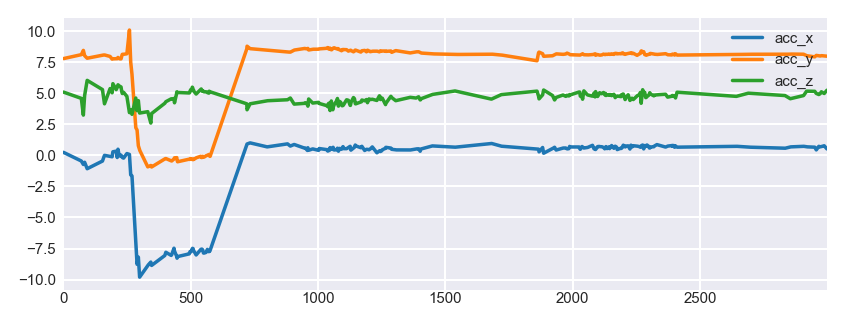

```
After Scaling:
```

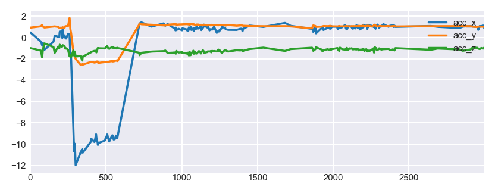

```
Validation Data:
Before Scaling:
```

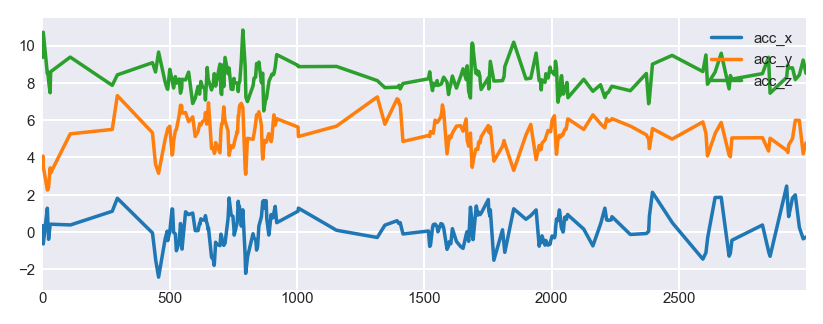

```
After Scaling:
```

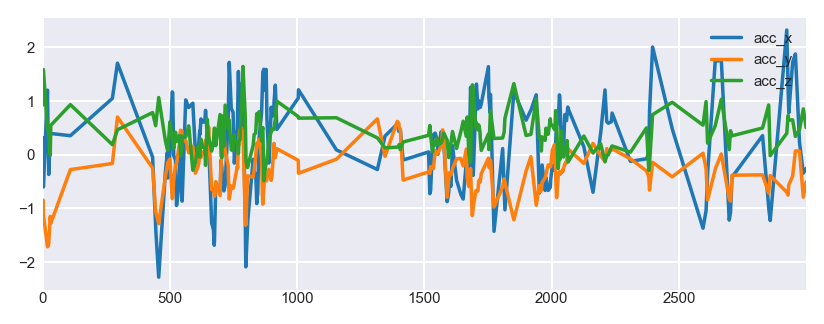

```python
if not P.scaler_global:
    print("Scaling Data for Siamese Network only...")
    print("Training Data:")
    hmog.valid_train, _ = utils_custom_scale(
        hmog.valid_train,
        scale_cols=P.feature_cols,
        feature_cols=P.feature_cols,
        scaler_name=P.scaler,
        scope=P.scaler_scope,
        plot=True,
    )
    print("Validation Data:")
    hmog.valid_test, _ = utils_custom_scale(
        hmog.valid_test,
        scale_cols=P.feature_cols,
        feature_cols=P.feature_cols,
        scaler_name=P.scaler,
        scope=P.scaler_scope,
        plot=True,
    )
else:
    print("Skipped, already normalized.")
```

### 2.5 Check Splits

```python
utils_split_report(hmog.valid_train)
```

```
Unique subjects: 40
Unique sessions: 960

Head:
```

|  | acc_x | acc_y | acc_z | gyr_x | gyr_y | gyr_z | mag_x | mag_y | mag_z | subject | session | task_type |
| --- | --- | --- | --- | --- | --- | --- | --- | --- | --- | --- | --- | --- |
| 0 | 0.465809 | 0.911635 | -1.006664 | 0.023729 | -0.087669 | -0.298940 | -17.868000 | 15.582000 | -30.400000 | 100669 | 100669_session_1 | 0 |
| 1 | 0.453490 | 0.913441 | -1.010034 | 0.024885 | -0.085446 | -0.296594 | -17.855675 | 15.556771 | -30.374313 | 100669 | 100669_session_1 | 0 |
| 2 | 0.441171 | 0.915247 | -1.013404 | 0.026041 | -0.083223 | -0.294248 | -17.843349 | 15.531542 | -30.348626 | 100669 | 100669_session_1 | 0 |
| 3 | 0.428853 | 0.917053 | -1.016774 | 0.027196 | -0.080999 | -0.291902 | -17.831024 | 15.506313 | -30.322939 | 100669 | 100669_session_1 | 0 |
| 4 | 0.416534 | 0.918858 | -1.020144 | 0.028352 | -0.078776 | -0.289556 | -17.818699 | 15.481084 | -30.297253 | 100669 | 100669_session_1 | 0 |

```
Sessions' Task Types per subject:
```

| subject | 100669 | 171538 | 201848 | 220962 | 261313 | 277905 | 278135 | 326223 | 342329 | 366286 | 368258 | 395129 | 398248 | 472761 | 489146 | 525584 | 527796 | 538363 | 540641 | 556357 | 588087 | 657486 | 693572 | 698266 | 710707 | 745224 | 763813 | 827212 | 863985 | … |
| --- | --- | --- | --- | --- | --- | --- | --- | --- | --- | --- | --- | --- | --- | --- | --- | --- | --- | --- | --- | --- | --- | --- | --- | --- | --- | --- | --- | --- | --- | --- |
| 1 | 4 | 4 | 4 | 4 | 4 | 4 | 4 | 4 | 4 | 4 | 4 | 4 | 4 | 4 | 4 | 4 | 4 | 4 | 4 | 4 | 4 | 4 | 4 | 4 | 4 | 4 | 4 | 4 | 4 | … |
| 2 | 4 | 4 | 4 | 4 | 4 | 4 | 4 | 4 | 4 | 4 | 4 | 4 | 4 | 4 | 4 | 4 | 4 | 4 | 4 | 4 | 4 | 4 | 4 | 4 | 4 | 4 | 4 | 4 | 4 | … |
| 3 | 4 | 4 | 4 | 4 | 4 | 4 | 4 | 4 | 4 | 4 | 4 | 4 | 4 | 4 | 4 | 4 | 4 | 4 | 4 | 4 | 4 | 4 | 4 | 4 | 4 | 4 | 4 | 4 | 4 | … |
| 4 | 4 | 4 | 4 | 4 | 4 | 4 | 4 | 4 | 4 | 4 | 4 | 4 | 4 | 4 | 4 | 4 | 4 | 4 | 4 | 4 | 4 | 4 | 4 | 4 | 4 | 4 | 4 | 4 | 4 | … |
| 5 | 4 | 4 | 4 | 4 | 4 | 4 | 4 | 4 | 4 | 4 | 4 | 4 | 4 | 4 | 4 | 4 | 4 | 4 | 4 | 4 | 4 | 4 | 4 | 4 | 4 | 4 | 4 | 4 | 4 | … |
| 6 | 4 | 4 | 4 | 4 | 4 | 4 | 4 | 4 | 4 | 4 | 4 | 4 | 4 | 4 | 4 | 4 | 4 | 4 | 4 | 4 | 4 | 4 | 4 | 4 | 4 | 4 | 4 | 4 | 4 | … |

```python
utils_split_report(hmog.valid_test)
```

```
Unique subjects: 10
Unique sessions: 240

Head:
```

|  | acc_x | acc_y | acc_z | gyr_x | gyr_y | gyr_z | mag_x | mag_y | mag_z | subject | session | task_type |
| --- | --- | --- | --- | --- | --- | --- | --- | --- | --- | --- | --- | --- |
| 0 | 0.318787 | -1.132553 | 0.923222 | -0.147524 | -0.934624 | -0.279471 | 7.943000 | 5.224000 | -36.376000 | 257279 | 257279_session_1 | 6 |
| 1 | 0.216407 | -0.990945 | 1.247177 | 0.630107 | -0.243430 | 0.318261 | 7.345000 | 5.270000 | -35.887000 | 257279 | 257279_session_1 | 6 |
| 2 | 0.114028 | -0.849338 | 1.571132 | 0.606610 | -0.255158 | 0.298632 | 7.364951 | 5.199424 | -35.843814 | 257279 | 257279_session_1 | 6 |
| 3 | -0.603578 | -1.116535 | 1.587604 | 0.583112 | -0.266887 | 0.279003 | 7.384902 | 5.128846 | -35.800626 | 257279 | 257279_session_1 | 6 |
| 4 | -0.490657 | -1.154155 | 1.519379 | 0.559613 | -0.278616 | 0.259373 | 7.404854 | 5.058267 | -35.757438 | 257279 | 257279_session_1 | 6 |

```
Sessions' Task Types per subject:
```

| subject | 257279 | 396697 | 554303 | 594887 | 621276 | 733568 | 777078 | 815316 | 923862 | 984799 |
| --- | --- | --- | --- | --- | --- | --- | --- | --- | --- | --- |
| 1 | 4 | 4 | 4 | 4 | 4 | 4 | 4 | 4 | 4 | 4 |
| 2 | 4 | 4 | 4 | 4 | 4 | 4 | 4 | 4 | 4 | 4 |
| 3 | 4 | 4 | 4 | 4 | 4 | 4 | 4 | 4 | 4 | 4 |
| 4 | 4 | 4 | 4 | 4 | 4 | 4 | 4 | 4 | 4 | 4 |
| 5 | 4 | 4 | 4 | 4 | 4 | 4 | 4 | 4 | 4 | 4 |
| 6 | 4 | 4 | 4 | 4 | 4 | 4 | 4 | 4 | 4 | 4 |

```python
utils_split_report(hmog.test_train)
```

```
Unique subjects: 10
Unique sessions: 240

Head:
```

|  | acc_x | acc_y | acc_z | gyr_x | gyr_y | gyr_z | mag_x | mag_y | mag_z | subject | session | task_type |
| --- | --- | --- | --- | --- | --- | --- | --- | --- | --- | --- | --- | --- |
| 0 | 1.476025 | 1.997363 | 8.796896 | 0.006720 | -0.016188 | -0.002138 | -13.156054 | 10.606357 | -10.698410 | 207696 | 207696_session_1 | 1 |
| 1 | 1.472228 | 1.996640 | 8.805110 | 0.007342 | -0.015554 | -0.002256 | -13.162250 | 10.576000 | -10.668250 | 207696 | 207696_session_1 | 1 |
| 2 | 1.468430 | 1.995918 | 8.813325 | 0.007965 | -0.014919 | -0.002373 | -13.168446 | 10.545643 | -10.638090 | 207696 | 207696_session_1 | 1 |
| 3 | 1.464632 | 1.995196 | 8.821540 | 0.008587 | -0.014285 | -0.002490 | -13.174643 | 10.515286 | -10.607929 | 207696 | 207696_session_1 | 1 |
| 4 | 1.460834 | 1.994473 | 8.829754 | 0.009210 | -0.013650 | -0.002608 | -13.180839 | 10.484928 | -10.577767 | 207696 | 207696_session_1 | 1 |

```
Sessions' Task Types per subject:
```

| subject | 207696 | 240168 | 352716 | 431312 | 578526 | 622852 | 776328 | 785899 | 856302 | 980953 |
| --- | --- | --- | --- | --- | --- | --- | --- | --- | --- | --- |
| 1 | 4 | 4 | 4 | 4 | 4 | 4 | 4 | 4 | 4 | 4 |
| 2 | 4 | 4 | 4 | 4 | 4 | 4 | 4 | 4 | 4 | 4 |
| 3 | 4 | 4 | 4 | 4 | 4 | 4 | 4 | 4 | 4 | 4 |
| 4 | 4 | 4 | 4 | 4 | 4 | 4 | 4 | 4 | 4 | 4 |
| 5 | 4 | 4 | 4 | 4 | 4 | 4 | 4 | 4 | 4 | 4 |
| 6 | 4 | 4 | 4 | 4 | 4 | 4 | 4 | 4 | 4 | 4 |

```python
utils_split_report(hmog.test_test)
```

```
Unique subjects: 30
Unique sessions: 720

Head:
```

|  | acc_x | acc_y | acc_z | gyr_x | gyr_y | gyr_z | mag_x | mag_y | mag_z | subject | session | task_type |
| --- | --- | --- | --- | --- | --- | --- | --- | --- | --- | --- | --- | --- |
| 0 | -1.277905 | 5.390545 | 7.082647 | -0.058948 | -0.057727 | -0.014966 | -33.239 | 24.833 | -51.906 | 151985 | 151985_session_1 | 1 |
| 1 | -1.329381 | 5.562329 | 6.672640 | -0.093004 | -0.048258 | 0.026878 | -33.082 | 24.833 | -51.750 | 151985 | 151985_session_1 | 1 |
| 2 | -1.330150 | 5.550244 | 6.693333 | -0.127060 | -0.038790 | 0.068722 | -33.082 | 24.833 | -51.750 | 151985 | 151985_session_1 | 1 |
| 3 | -1.330920 | 5.538159 | 6.714026 | -0.177151 | -0.095906 | 0.057421 | -33.082 | 24.833 | -51.750 | 151985 | 151985_session_1 | 1 |
| 4 | -1.331689 | 5.526074 | 6.734719 | -0.231212 | -0.123089 | 0.047647 | -33.082 | 24.833 | -51.750 | 151985 | 151985_session_1 | 1 |

```
Sessions' Task Types per subject:
```

| subject | 151985 | 180679 | 186676 | 218719 | 248252 | 264325 | 336172 | 405035 | 501973 | 553321 | 561993 | 579284 | 663153 | 675397 | 717868 | 720193 | 751131 | 771782 | 785873 | 799296 | 803262 | 808022 | 841866 | 862649 | 865881 | 893198 | 913228 | 937904 | 962159 | … |
| --- | --- | --- | --- | --- | --- | --- | --- | --- | --- | --- | --- | --- | --- | --- | --- | --- | --- | --- | --- | --- | --- | --- | --- | --- | --- | --- | --- | --- | --- | --- |
| 1 | 4 | 4 | 4 | 4 | 4 | 4 | 4 | 4 | 4 | 4 | 4 | 4 | 4 | 4 | 4 | 4 | 4 | 4 | 4 | 4 | 4 | 4 | 4 | 4 | 4 | 4 | 4 | 4 | 4 | … |
| 2 | 4 | 4 | 4 | 4 | 4 | 4 | 4 | 4 | 4 | 4 | 4 | 4 | 4 | 4 | 4 | 4 | 4 | 4 | 4 | 4 | 4 | 4 | 4 | 4 | 4 | 4 | 4 | 4 | 4 | … |
| 3 | 4 | 4 | 4 | 4 | 4 | 4 | 4 | 4 | 4 | 4 | 4 | 4 | 4 | 4 | 4 | 4 | 4 | 4 | 4 | 4 | 4 | 4 | 4 | 4 | 4 | 4 | 4 | 4 | 4 | … |
| 4 | 4 | 4 | 4 | 4 | 4 | 4 | 4 | 4 | 4 | 4 | 4 | 4 | 4 | 4 | 4 | 4 | 4 | 4 | 4 | 4 | 4 | 4 | 4 | 4 | 4 | 4 | 4 | 4 | 4 | … |
| 5 | 4 | 4 | 4 | 4 | 4 | 4 | 4 | 4 | 4 | 4 | 4 | 4 | 4 | 4 | 4 | 4 | 4 | 4 | 4 | 4 | 4 | 4 | 4 | 4 | 4 | 4 | 4 | 4 | 4 | … |
| 6 | 4 | 4 | 4 | 4 | 4 | 4 | 4 | 4 | 4 | 4 | 4 | 4 | 4 | 4 | 4 | 4 | 4 | 4 | 4 | 4 | 4 | 4 | 4 | 4 | 4 | 4 | 4 | 4 | 4 | … |

### 2.6 Reshape Features

**Reshape & cache Set for Training Siamese Network:**

```python
df_siamese_train = utils_reshape_features(
    hmog.valid_train,
    feature_cols=P.feature_cols,
    window_size=P.window_size,
    step_width=P.step_width,
)

# Clean memory
del hmog.train
%reset_selective -f hmog.train

print("Validation data after reshaping:")
display(df_siamese_train.head())

# Store iterim data
df_siamese_train.to_msgpack(OUTPUT_PATH / "df_siamese_train.msg")

# Clean memory
%reset_selective -f df_siamese_train
```

```
Validation data after reshaping:
```

|  | X | subject | session | task_type |
| --- | --- | --- | --- | --- |
| 0 | [[0.4658093154931841, 0.9116351246391354, -1.0... | 100669 | 100669_session_1 | 1 |
| 1 | [[-9.443088677020931, -2.2863482147217318, -0.... | 100669 | 100669_session_1 | 1 |
| 2 | [[0.6764168861710826, 1.2124697736470507, -1.3... | 100669 | 100669_session_1 | 1 |
| 3 | [[1.030803333953206, 1.0515319083860362, -1.01... | 100669 | 100669_session_1 | 1 |
| 4 | [[1.00135078580074, 1.0328959462625564, -1.082... | 100669 | 100669_session_1 | 1 |

**Reshape & cache Set for Validating Siamese Network:** (also used to optimize OCSVM)

```python
df_siamese_valid = utils_reshape_features(
    hmog.valid_test,
    feature_cols=P.feature_cols,
    window_size=P.window_size,
    step_width=P.step_width,
)

del hmog.valid
%reset_selective -f hmog.valid

print("Testing data after reshaping:")
display(df_siamese_valid.head())

# Store iterim data
df_siamese_valid.to_msgpack(OUTPUT_PATH / "df_siamese_valid.msg")

# Clean memory
%reset_selective -f df_siamese_valid
```

```
Testing data after reshaping:
```

|  | X | subject | session | task_type |
| --- | --- | --- | --- | --- |
| 0 | [[0.31878702208669574, -1.132552899188318, 0.9... | 257279 | 257279_session_1 | 6 |
| 1 | [[0.01691649201424336, -0.08293418848599196, 0... | 257279 | 257279_session_1 | 6 |
| 2 | [[1.0273605165014035, -0.09580762019971102, 0.... | 257279 | 257279_session_1 | 6 |
| 3 | [[0.02601782729002675, -0.34596581903884127, 0... | 257279 | 257279_session_1 | 6 |
| 4 | [[-0.2855196463289382, -0.02352440984379223, 0... | 257279 | 257279_session_1 | 6 |

**Reshape & cache Set for Training/Validation OCSVM:**

```python
df_ocsvm_train_valid = utils_reshape_features(
    hmog.test_train,
    feature_cols=P.feature_cols,
    window_size=P.window_size,
    step_width=P.step_width,
)

del hmog.test_train
%reset_selective -f hmog.test_train

print("Testing data after reshaping:")
display(df_ocsvm_train_valid.head())

# Store iterim data
df_ocsvm_train_valid.to_msgpack(OUTPUT_PATH / "df_ocsvm_train_valid.msg")

# Clean memory
%reset_selective -f df_ocsvm_train_valid
```

```
Testing data after reshaping:
```

|  | X | subject | session | task_type |
| --- | --- | --- | --- | --- |
| 0 | [[1.4760253, 1.9973627, 8.796896], [1.47222764... | 207696 | 207696_session_1 | 1 |
| 1 | [[0.9260304840056645, 2.394303759306227, 8.804... | 207696 | 207696_session_1 | 1 |
| 2 | [[0.9333921612905007, 2.520338366638342, 8.772... | 207696 | 207696_session_1 | 1 |
| 3 | [[2.18874907550208, 7.162553906657281, 5.32619... | 207696 | 207696_session_1 | 1 |
| 4 | [[1.2906508848917835, 7.543988918287735, 5.085... | 207696 | 207696_session_1 | 1 |

**Reshape & cache Set for Training/Testing OCSVM:**

```python
df_ocsvm_train_test = utils_reshape_features(
    hmog.test_test,
    feature_cols=P.feature_cols,
    window_size=P.window_size,
    step_width=P.step_width,
)

del hmog.test_test
%reset_selective -f hmog.test_test

print("Testing data after reshaping:")
display(df_ocsvm_train_test.head())

# Store iterim data
df_ocsvm_train_test.to_msgpack(OUTPUT_PATH / "df_ocsvm_train_test.msg")

# Clean memory
%reset_selective -f df_ocsvm_train_test
%reset_selective -f df_
```

```
Testing data after reshaping:
```

|  | X | subject | session | task_type |
| --- | --- | --- | --- | --- |
| 0 | [[-1.2779051000000001, 5.3905449999999995, 7.0... | 151985 | 151985_session_1 | 1 |
| 1 | [[-2.1210234, 6.35229608, 6.313509860000001], ... | 151985 | 151985_session_1 | 1 |
| 2 | [[-1.8303672154844837, 6.066564922061926, 6.47... | 151985 | 151985_session_1 | 1 |
| 3 | [[-1.6831238000000002, 5.390305785640307, 7.11... | 151985 | 151985_session_1 | 1 |
| 4 | [[-1.52979505, 5.552054166666667, 7.0235900666... | 151985 | 151985_session_1 | 1 |

## 3. Generate Scenario Pairs

### 3.1 Load cached Data

```python
df_siamese_train = pd.read_msgpack(OUTPUT_PATH / "df_siamese_train.msg")
df_siamese_valid = pd.read_msgpack(OUTPUT_PATH / "df_siamese_valid.msg")
```

### 3.2 Build positive/negative Pairs

```python
def build_pairs(df):
    # Limit samples per subject to sample of shortest session
    df = df.groupby("session", group_keys=False).apply(
        lambda x: x.sample(min(len(x), P.max_pairs_per_session), random_state=SEED)
    )
    df_pairs = None

    # Split samples subject wise 50:50
    # ---------------
    df_positives = None
    df_negatives = None

    for subject in df["subject"].unique():
        # Shuffle
        df_subj = df[df["subject"] == subject].sample(frac=1, random_state=SEED)

        # Make rows even
        if len(df_subj) % 2 != 0:
            df_subj = df_subj.iloc[:-1]

        half = len(df_subj) // 2

        df_positives = pd.concat([df_positives, df_subj.iloc[:half]])
        df_negatives = pd.concat([df_negatives, df_subj.iloc[half:]])

    # Positive Pairs
    # ---------------
    df_positive_left = None
    df_positive_right = None

    for subject in df_positives["subject"].unique():
        df_subj = df[df["subject"] == subject]
        # Make rows even
        if len(df_subj) % 2 != 0:
            df_subj = df_subj.iloc[:-1]

        # Split in half
        half = len(df_subj) // 2
        df_positive_left = pd.concat([df_positive_left, df_subj.iloc[:half]])
        df_positive_right = pd.concat([df_positive_right, df_subj.iloc[half:]])

    df_positive_left = df_positive_left.reset_index(drop=True)
    df_positive_right = df_positive_right.reset_index(drop=True)
    df_positive_left.columns = ["left_" + c for c in df_positive_left.columns]
    df_positive_right.columns = ["right_" + c for c in df_positive_right.columns]

    df_positives = pd.concat(
        [df_positive_left, df_positive_right],
        axis=1,
        sort=False,
        join_axes=[df_positive_left.index],
    )

    # Negative Pairs
    # ---------------
    # Make rows even
    if len(df_negatives) % 2 != 0:
        df_negatives = df_negatives.iloc[:-1]

    # Split in half
    half = len(df_negatives) // 2
    df_negative_left = df_negatives.iloc[half:].reset_index(drop=True)
    df_negative_right = df_negatives.iloc[:half].reset_index(drop=True)

    # Name columns
    df_negative_left.columns = ["left_" + c for c in df_negative_left.columns]
    df_negative_right.columns = ["right_" + c for c in df_negative_right.columns]

    # Combine
    df_negatives = pd.concat(
        [df_negative_left, df_negative_right],
        axis=1,
        sort=False,
        join_axes=[df_negative_left.index],
    )

    # Combine both Pairs
    # ---------------
    # Balance pairs
    min_len = min(len(df_positives), len(df_negatives))
    df_positives = df_positives.sample(n=min_len, random_state=SEED)
    df_negatives = df_negatives.sample(n=min_len, random_state=SEED)

    # Combine
    df_pairs = pd.concat([df_positives, df_negatives], sort=False)

    # Shuffle
    df_pairs = df_pairs.sample(frac=1, random_state=SEED).reset_index(drop=True)

    # Set Label
    df_pairs["label"] = np.where(
        df_pairs["left_subject"] == df_pairs["right_subject"], 1, 0
    )

    return df_pairs
```

```python
# Reduce observations/samples per
print("Sample per session before reduction:\n ")
display(df_siamese_train["session"].value_counts().head(3))
display(df_siamese_valid["session"].value_counts().head(3))

df_siamese_train = df_siamese_train.groupby("session", group_keys=False).apply(
    lambda x: x.sample(n=min(len(x), P.samples_per_subject_train), random_state=SEED)
)

df_siamese_valid = df_siamese_valid.groupby("session", group_keys=False).apply(
    lambda x: x.sample(n=min(len(x), P.samples_per_subject_test), random_state=SEED)
)

print("\n\nSample per session after reduction:\n")
display(df_siamese_train["session"].value_counts().head(3))
display(df_siamese_valid["session"].value_counts().head(3))
```

```
Sample per session before reduction:
```

```
527796_session_2    387
876011_session_4    339
278135_session_2    312
Name: session, dtype: int64
```

```
733568_session_2    417
396697_session_1    330
621276_session_1    286
Name: session, dtype: int64
```

```
Sample per session after reduction:
```

```
556357_session_9     14
872895_session_23    14
763813_session_2     14
Name: session, dtype: int64
```

```
815316_session_19    14
621276_session_14    14
396697_session_13    14
Name: session, dtype: int64
```

```python
df_siamese_train_pairs = build_pairs(df_siamese_train)
df_siamese_valid_pairs = build_pairs(df_siamese_valid)
```

### 3.3 Inspect Pairs

```
DataFrame Info:
<class 'pandas.core.frame.DataFrame'>
RangeIndex: 6720 entries, 0 to 6719
Data columns (total 9 columns):
left_X             6720 non-null object
left_subject       6720 non-null object
left_session       6720 non-null object
left_task_type     6720 non-null int64
right_X            6720 non-null object
right_subject      6720 non-null object
right_session      6720 non-null object
right_task_type    6720 non-null int64
label              6720 non-null int32
dtypes: int32(1), int64(2), object(6)
memory usage: 446.3+ KB
```

```
None
```

```
Head:
```

|  | left_X | left_subject | left_session | left_task_type | right_X | right_subject | right_session | right_task_type | label |
| --- | --- | --- | --- | --- | --- | --- | --- | --- | --- |
| 0 | ((-0.17182153956657137, -0.8091310841360172, 0... | 698266 | 698266_session_20 | 6 | ((-0.20034259316859354, 0.297408549632444, 0.5... | 220962 | 220962_session_20 | 2 | 0 |
| 1 | ((0.22143075837026474, -0.0022313092556529844,... | 693572 | 693572_session_11 | 2 | ((0.17366707891110025, 0.4483884663609091, -0.... | 201848 | 201848_session_11 | 1 | 0 |
| 2 | ((-0.1500758008948674, 0.15339020529959504, -0... | 395129 | 395129_session_1 | 3 | ((-1.4657600068784042, 0.760045192517478, -1.2... | 395129 | 395129_session_20 | 2 | 1 |
| 3 | ((0.5639576177483655, 0.2919554768240122, -0.7... | 745224 | 745224_session_5 | 1 | ((-1.1076282375435977, 0.48435805066642124, -0... | 277905 | 277905_session_5 | 1 | 0 |
| 4 | ((0.04999637832266275, 1.1560975445196484, -1.... | 710707 | 710707_session_14 | 1 | ((0.2369560807181296, 0.2084818886589981, -0.1... | 261313 | 261313_session_14 | 6 | 0 |

```
Any NaN values?
```

```
left_X             0
left_subject       0
left_session       0
left_task_type     0
right_X            0
right_subject      0
right_session      0
right_task_type    0
label              0
dtype: int64
```

```
Distribution of Samples per Subjects in training Data
```

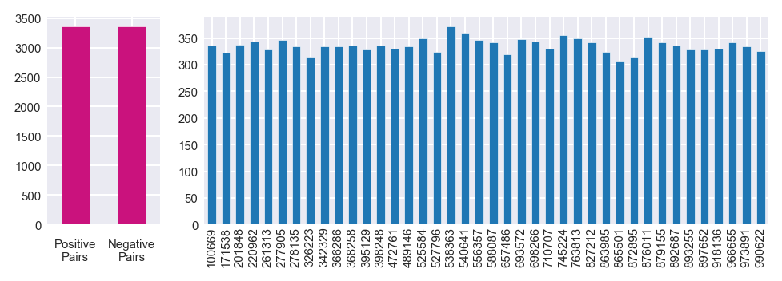

```python
print("DataFrame Info:")
display(df_siamese_train_pairs.info())

print("\n\nHead:")
display(df_siamese_train_pairs.head(5))

print("\n\nAny NaN values?")
display(df_siamese_train_pairs.isnull().sum(axis = 0))

df_left_sub = df_siamese_train_pairs.groupby("left_subject")["left_subject"].count()
df_right_sub = df_siamese_train_pairs.groupby("right_subject")["right_subject"].count()
df_temp = pd.concat([df_left_sub, df_right_sub])

print("\n\n\nDistribution of Samples per Subjects in training Data")

fig, axes = plt.subplots(
    ncols=2, nrows=1, figsize=(5.473, 2), dpi=180, gridspec_kw={"width_ratios": [1, 5]}
)
df_siamese_train_pairs["label"].value_counts().rename(
    index={0: "Negative\nPairs", 1: "Positive\nPairs"}
).plot.bar(ax=axes[0], rot=0, color=MAGENTA)
axes[0].tick_params(axis="x", which="major", pad=7)
df_temp.groupby(df_temp.index).sum().plot.bar(ax=axes[1], width=0.6)
fig.tight_layout()

utils_save_plot(plt, REPORT_PATH / f"buech2019-siamese-{P.name.lower()}-pair-dist.pdf")
```

### 3.4 Cache Pairs

```python
df_siamese_train_pairs.to_msgpack(OUTPUT_PATH / "df_siamese_train_pairs.msg")
df_siamese_valid_pairs.to_msgpack(OUTPUT_PATH / "df_siamese_valid_pairs.msg")
```

```python
# Clean Memory
%reset_selective -f df_
```

## 4. Siamese Network

### 4.1 Load cached Pairs

```python
df_siamese_train_pairs = pd.read_msgpack(OUTPUT_PATH / "df_siamese_train_pairs.msg")
df_siamese_valid_pairs = pd.read_msgpack(OUTPUT_PATH / "df_siamese_valid_pairs.msg")
```

### 4.2 Build Model

#### Distance Function

```python
def k_euclidean_dist(t):
    x = t[0]
    y = t[1]
    return K.sqrt(K.sum(K.square(x - y), axis=-1, keepdims=True))
```

#### Loss Function

```python
def k_contrastive_loss(y_true, dist):
    """Contrastive loss from Hadsell-et-al.'06
    http://yann.lecun.com/exdb/publis/pdf/hadsell-chopra-lecun-06.pdf
    """
    margin = P.margin
    return K.mean(y_true * K.square(dist) + (1 - y_true) * K.square(K.maximum(margin - dist, 0)))
```

Sanity check contrastive loss function:

```python
def contrastive_loss_test(y_true, dist):
    """Test function above using implementation with numpy instead tensors."""
    margin = P.margin
    return y_true * np.square(dist) + (1 - y_true) * np.square(np.max(margin - dist, 0))
```

```python
print("Positive: class=1, distance=0,     loss:", contrastive_loss_test(1, 0))
print("Positive: class=1, distance=0.01,  loss:", contrastive_loss_test(1, 0.01))
print("Positive: class=1, distance=0.3,   loss:", contrastive_loss_test(1, 0.3))
print("Positive: class=1, distance=0.5,   loss:", contrastive_loss_test(1, 0.5))
print("Positive: class=1, distance=1,     loss:", contrastive_loss_test(1, 1))
```

```
Positive: class=1, distance=0,     loss: 0
Positive: class=1, distance=0.01,  loss: 0.0001
Positive: class=1, distance=0.3,   loss: 0.09
Positive: class=1, distance=0.5,   loss: 0.25
Positive: class=1, distance=1,     loss: 1
```

```python
print("Negative: class=0, distance=0,     loss:", contrastive_loss_test(0, 0))
print("Negative: class=0, distance=0.01,  loss:", contrastive_loss_test(0, 0.01))
print("Negative: class=0, distance=0.3,   loss:", contrastive_loss_test(0, 0.3))
print("Negative: class=0, distance=0.5,   loss:", contrastive_loss_test(0, 0.5))
print("Negative: class=0, distance=5,     loss:", contrastive_loss_test(0, 1))
```

```
Negative: class=0, distance=0,     loss: 1
Negative: class=0, distance=0.01,  loss: 0.9801
Negative: class=0, distance=0.3,   loss: 0.48999999999999994
Negative: class=0, distance=0.5,   loss: 0.25
Negative: class=0, distance=5,     loss: 0
```

#### Siamese Model with 2D Filters, as derived from Centeno et al. (2018)

```python
def build_model_2d(input_shape, filters):
    """
        Siamese CNN architecture with 3D input and 2D filters
    """
    # Define the tensors for the two input images
    left_inputs = Input(input_shape, name="left_inputs")
    right_inputs = Input(input_shape, name="right_inputs")

    # Convolutional Neural Network
    inputs = Input(input_shape, name="input")
    x = Conv2D(filters[0], (7, 7), padding="same", activation="tanh", name="conv1")(inputs)
    x = MaxPooling2D(pool_size=(2, 2), padding="same", name="mp1")(x)
    x = Conv2D(filters[1], (5, 5), padding="same", activation="tanh", name="conv2")(x)
    x = MaxPooling2D(pool_size=(2, 2), padding="same", name="mp2")(x)
    x = Conv2D(filters[2], (3, 3), padding="same", activation="tanh", name="conv3")(x)
    x = MaxPooling2D(pool_size=(2, 2), padding="same", name="mp3")(x)
    x = Conv2D(filters[3], (3, 3), padding="same", activation="tanh", name="conv4")(x)
    x = MaxPooling2D(pool_size=(2, 2), padding="same", name="mp4")(x)
    x = Flatten(name="flat")(x)

    # Basemodel instance
    basemodel = Model(inputs, x, name="basemodel")

    # using same instance of "basemodel" to share weights between left/right networks
    encoded_l = basemodel(left_inputs)
    encoded_r = basemodel(right_inputs)

    # Add a customized layer to compute the distance between the encodings
    distance_layer = Lambda(k_euclidean_dist, name="distance")([encoded_l, encoded_r])

    # Combine into one net
    siamese_net = Model(inputs=[left_inputs, right_inputs], outputs=distance_layer)

    # return the model
    return siamese_net, basemodel
```

#### Siamese Model with 1D Filters, similar than Centeno et al. (2018)

```python
def build_model_1d(input_shape, filters):
    """
        Model architecture
    """
    # Define the tensors for the two input images
    left_inputs = Input(input_shape, name="left_inputs")
    right_inputs = Input(input_shape, name="right_inputs")

    # Convolutional Neural Network
    inputs = Input(input_shape, name="input")
    x = Conv1D(filters[0], 7, activation="elu", padding="same", name="conv1")(inputs)
    x = MaxPooling1D(pool_size=2, name="mp1")(x)
    x = Conv1D(filters[1], 5, activation="elu", padding="same", name="conv2")(x)
    x = MaxPooling1D(pool_size=2, name="mp2")(x)
    x = Conv1D(filters[2], 3, activation="elu", padding="same", name="conv3")(x)
    x = MaxPooling1D(pool_size=2, name="mp3")(x)
    x = Conv1D(filters[3], 3, activation="elu", padding="same", name="conv4")(x)
    x = MaxPooling1D(pool_size=2, name="mp5")(x)
    x = Flatten(name="flat")(x)

    # Generate the encodings (feature vectors) for the two images
    basemodel = Model(inputs, x, name="basemodel")

    # using same instance of "basemodel" to share weights between left/right networks
    encoded_l = basemodel(left_inputs)
    encoded_r = basemodel(right_inputs)

    # Add a customized layer to compute the absolute difference between the encodings
    distance_layer = Lambda(k_euclidean_dist, name="distance")([encoded_l, encoded_r])

    siamese_net = Model(inputs=[left_inputs, right_inputs], outputs=distance_layer)

    # return the model
    return siamese_net, basemodel
```

#### Siamese Model with FCN architecture

```python
def build_model_fcn(input_shape, filters):
    # Define the tensors for the two input images
    left_inputs = Input(input_shape, name="left_inputs")
    right_inputs = Input(input_shape, name="right_inputs")

    # Convolutional Neural Network
    inputs = Input(input_shape, name="input")
    x = Conv1D(
        filters=filters[0],
        kernel_size=8,
        strides=1,
        activation=None,
        padding="same",
        name="conv1",
    )(inputs)
    x = BatchNormalization()(x)
    x = Activation("relu")(x)
    x = Dropout(0.1, name="drop1")(x)
    x = Conv1D(
        filters=filters[1],
        kernel_size=5,
        strides=1,
        activation=None,
        padding="same",
        name="conv2",
    )(x)
    x = BatchNormalization()(x)
    x = Activation("relu")(x)
    x = Dropout(0.1, name="drop2")(x)
    x = Conv1D(
        filters=filters[2],
        kernel_size=3,
        strides=1,
        activation=None,
        padding="same",
        name="conv3",
    )(x)
    x = BatchNormalization()(x)
    x = Activation("relu")(x)
    x = GlobalAveragePooling1D()(x)
    x = Dense(32, activation="sigmoid", name="dense")(x)

    # Basemodel instance
    basemodel = Model(inputs, x, name="basemodel")

    # using same instance of "basemodel" to share weights between left/right networks
    encoded_l = basemodel(left_inputs)
    encoded_r = basemodel(right_inputs)

    # Add a customized layer to compute the distance between the encodings
    distance_layer = Lambda(k_euclidean_dist, name="distance")([encoded_l, encoded_r])

    # Combine into one net
    siamese_net = Model(inputs=[left_inputs, right_inputs], outputs=distance_layer)

    # return the model
    return siamese_net, basemodel
```

```python
def get_model(name, window_size, feature_cols, filters):
    print(f"Using Model variant {name}...")
    if name == "1d":
        model, basemodel = build_model_1d((window_size, len(feature_cols)), filters)
    elif name == "2d":
        model, basemodel = build_model_2d((window_size, len(feature_cols), 1), filters)
    elif name == "fcn":
        model, basemodel = build_model_fcn((window_size, len(feature_cols)), filters)
    else:
        raise BaseException("Error: Not a valid model name: {1d, 2d, fcn}")

    return model, basemodel
```

**Inspect model architecture:**

```python
temp_model, temp_basemodel = get_model(P.model_variant, P.window_size, P.feature_cols, P.filters)

temp_basemodel.summary()
temp_model.summary()
```

```
Using Model variant fcn...
_________________________________________________________________
Layer (type)                 Output Shape              Param #
=================================================================
input (InputLayer)           (None, 500, 3)            0
_________________________________________________________________
conv1 (Conv1D)               (None, 500, 32)           800
_________________________________________________________________
batch_normalization_1 (Batch (None, 500, 32)           128
_________________________________________________________________
activation_1 (Activation)    (None, 500, 32)           0
_________________________________________________________________
drop1 (Dropout)              (None, 500, 32)           0
_________________________________________________________________
conv2 (Conv1D)               (None, 500, 64)           10304
_________________________________________________________________
batch_normalization_2 (Batch (None, 500, 64)           256
_________________________________________________________________
activation_2 (Activation)    (None, 500, 64)           0
_________________________________________________________________
drop2 (Dropout)              (None, 500, 64)           0
_________________________________________________________________
conv3 (Conv1D)               (None, 500, 32)           6176
_________________________________________________________________
batch_normalization_3 (Batch (None, 500, 32)           128
_________________________________________________________________
activation_3 (Activation)    (None, 500, 32)           0
_________________________________________________________________
global_average_pooling1d_1 ( (None, 32)                0
_________________________________________________________________
dense (Dense)                (None, 32)                1056
=================================================================
Total params: 18,848
Trainable params: 18,592
Non-trainable params: 256
_________________________________________________________________
__________________________________________________________________________________________________
Layer (type)                    Output Shape         Param #     Connected to
==================================================================================================
left_inputs (InputLayer)        (None, 500, 3)       0
__________________________________________________________________________________________________
right_inputs (InputLayer)       (None, 500, 3)       0
__________________________________________________________________________________________________
basemodel (Model)               (None, 32)           18848       left_inputs[0][0]
                                                                 right_inputs[0][0]
__________________________________________________________________________________________________
distance (Lambda)               (None, 1)            0           basemodel[1][0]
                                                                 basemodel[2][0]
==================================================================================================
Total params: 18,848
Trainable params: 18,592
Non-trainable params: 256
__________________________________________________________________________________________________
```

### 4.3 Prepare Features

```python
def prep_X_y_pair(df):

    X_left = np.stack(list(df["left_X"].values))
    X_right = np.stack(list(df["right_X"].values))

    X = [X_left, X_right]
    y = df["label"].values

    return X, y
```

```python
X_train, y_train = prep_X_y_pair(df_siamese_train_pairs)
X_valid, y_valid = prep_X_y_pair(df_siamese_valid_pairs)

# 2D Filter Model needs flat 4th dimension
if P.model_variant == "2d":
    X_train[0] = X_train[0].reshape((*X_train[0].shape, 1))
    X_train[1] = X_train[1].reshape((*X_train[1].shape, 1))
    X_valid[0] = X_valid[0].reshape((*X_valid[0].shape, 1))
    X_valid[1] = X_valid[1].reshape((*X_valid[1].shape, 1))

print(
    f"Training samples:   {y_train.shape[0]}, shape: {X_train[0].shape},"
    + f" class balance: {np.unique(y_train, return_counts=True)}"
)
print(
    f"Validation samples: {y_valid.shape[0]}, shape: {X_valid[0].shape},"
    + f" class balance: {np.unique(y_valid, return_counts=True)}"
)
```

```
Training samples:   6720, shape: (6720, 500, 3), class balance: (array([0, 1]), array([3360, 3360], dtype=int64))
Validation samples: 1680, shape: (1680, 500, 3), class balance: (array([0, 1]), array([840, 840], dtype=int64))
```

### 4.4 Search optimal Epoch

```python
class MetricsCallback(Callback):
    """
    Custom Keras Callback function.

    Used to predict and plot distances for positive and negative pairs
    after each n-th epoch, along with some 'classification' metrics.
    'Classification' here means to ability to distinguish between positive
    and negative pairs using a threshold for the distance.

    Arguments:
        payload {tuple}           -- Datasets used for evaluation: (X_valid, y_valid, X_train, y_train)
        epoch_evaluate_freq {int} -- Frequency for evaluation. After every n-th epoch,
                                     the results are evaluated and printed
        save_plots {boolean}      -- Do you want to save plots as PDF? Path is configured via global
                                     parameter REPORT_PATH.
    """

    def __init__(self, payload, epoch_evaluate_freq=1, save_plots=False):

        self.X_valid, self.y_valid, self.X_train, self.y_train = payload
        self.save_plots = save_plots
        self.epoch_evaluate_freq = epoch_evaluate_freq

        # Do we have train and valid set?
        self.sets = []
        if self.X_train:
            self.sets.append([self.X_train, self.y_train, "Train"])
        if self.X_valid:
            self.sets.append([self.X_valid, self.y_valid, "Valid"])

    def on_train_begin(self, logs={}):
        print(32 * "=" + f"[ Initial State ]" + 32 * "=", end="")
        for X, y, desc in self.sets:
            self.evaluate(X, y, logs, desc, -1)

    def on_train_end(self, logs={}):
        print(32 * "=" + f"[ Final State ]" + 32 * "=", end="")
        for X, y, desc in self.sets:
            self.evaluate(X, y, logs, desc, -1)

    def on_epoch_end(self, epoch, logs={}):
        print(32 * "=" + f"[   Epoch {epoch}   ]" + 32 * "=", end="")
        if epoch % self.epoch_evaluate_freq == 0:  # Evaluate only every n-th epoch
            for X, y, desc in self.sets:
                self.evaluate(X, y, logs, desc, epoch)
        else:
            print()

    def evaluate(self, X, y, logs, desc, epoch):
        # Predict
        y_score = self.model.predict(X)
        y_score_neg = y_score * -1  # lower distance means closer to positive class

        # Calc Metrics
        roc_val = metrics.roc_auc_score(y, y_score_neg)
        eer_val, thres = utils_eer(y, y_score_neg, True)
        y_pred = np.where(y_score_neg > thres, 1, 0)
        acc_val = metrics.accuracy_score(y, y_pred)
        f1_val = metrics.f1_score(y, y_pred)

        print(
            f"\n{desc.upper()}: roc_auc: {roc_val:.4f}, "
            + f"eer: {eer_val:.4f}, thres: {thres*-1:.4f} => "
            + f"acc: {acc_val:.4f}, f1: {f1_val:.4f}\n"
            + f"{ ', '.join([k + ': ' + f'{v:.3f}' for k,v in logs.items()]) }"
        )

        # Plot distances
        mask = np.where(y == 1, True, False)
        dist_positive = y_score[mask]
        dist_negative = y_score[~mask]
        plt = utils_plot_distance_hist(
            dist_positive, dist_negative, thres * -1, desc=desc, margin=P.margin
        )

        if self.save_plots:
            utils_save_plot(
                plt,
                REPORT_PATH
                / f"buech2019-siamese-{P.name.lower()}-epoch-{epoch+1}-{desc.lower()}.pdf",
            )

        plt.show()
```

```python
def get_optimizer(name, lr=None, decay=None):
    if name == "sgd":
        lr = lr if lr != None else 0.01
        decay = decay if decay != None else 0
        optimizer = SGD(lr=lr, decay=decay)
    elif name == "adam":
        lr = lr if lr != None else 0.001
        decay = decay if decay != None else 0
        optimizer = Adam(lr=lr, decay=decay)
    elif name == "rmsprop":
        lr = lr if lr != None else 0.001
        optimizer = RMSprop(lr=lr)
    else:
        raise BaseException("Error: Not a valid model name: 1d or 2d.")
    return optimizer
```

```
Using Model variant fcn...
```

```
================================[ Initial State ]================================
TRAIN: roc_auc: 0.5297, eer: 0.4813, thres: 0.0805 => acc: 0.5186, f1: 0.5185
```

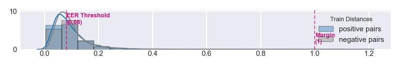

```
VALID: roc_auc: 0.4899, eer: 0.5071, thres: 0.0858 => acc: 0.4929, f1: 0.4929
```

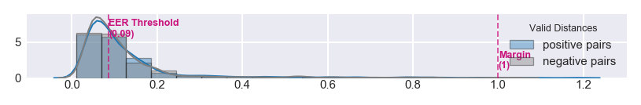

```
================================[   Epoch 0   ]================================
TRAIN: roc_auc: 0.5884, eer: 0.4440, thres: 0.4621 => acc: 0.5561, f1: 0.5560
val_loss: 0.280, loss: 0.279
```

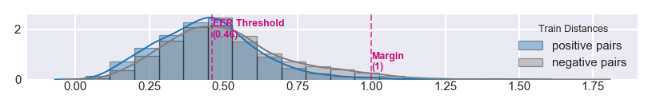

```
VALID: roc_auc: 0.5328, eer: 0.4726, thres: 0.4740 => acc: 0.5280, f1: 0.5283
val_loss: 0.280, loss: 0.279
```

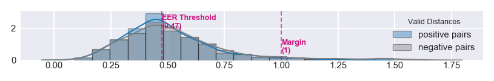

```
================================[   Epoch 1   ]================================
================================[   Epoch 2   ]================================
================================[   Epoch 3   ]================================
================================[   Epoch 4   ]================================
================================[   Epoch 5   ]================================
TRAIN: roc_auc: 0.6551, eer: 0.4009, thres: 0.4896 => acc: 0.5993, f1: 0.5992
val_loss: 0.261, loss: 0.233
```

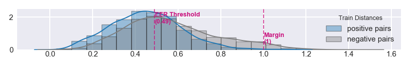

```
VALID: roc_auc: 0.5607, eer: 0.4607, thres: 0.5088 => acc: 0.5387, f1: 0.5379
val_loss: 0.261, loss: 0.233
```

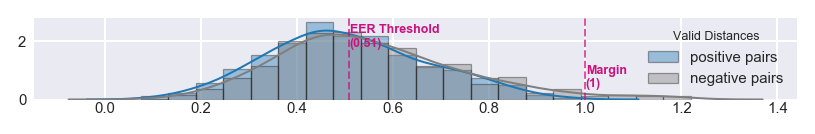

```
================================[   Epoch 6   ]================================
================================[   Epoch 7   ]================================
================================[   Epoch 8   ]================================
================================[   Epoch 9   ]================================
================================[   Epoch 10   ]================================
TRAIN: roc_auc: 0.6802, eer: 0.3756, thres: 0.5104 => acc: 0.6246, f1: 0.6246
val_loss: 0.260, loss: 0.226
```

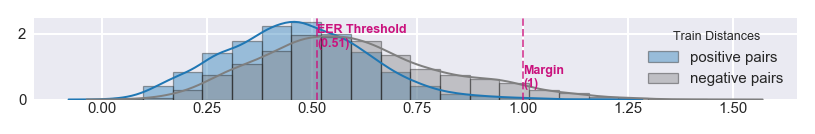

```
VALID: roc_auc: 0.5673, eer: 0.4601, thres: 0.5352 => acc: 0.5393, f1: 0.5393
val_loss: 0.260, loss: 0.226
```

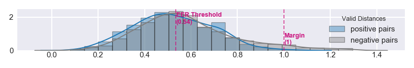

```
================================[   Epoch 11   ]================================
================================[   Epoch 12   ]================================
================================[   Epoch 13   ]================================
================================[   Epoch 14   ]================================
================================[   Epoch 15   ]================================
TRAIN: roc_auc: 0.6898, eer: 0.3708, thres: 0.5022 => acc: 0.6290, f1: 0.6289
val_loss: 0.252, loss: 0.224
```

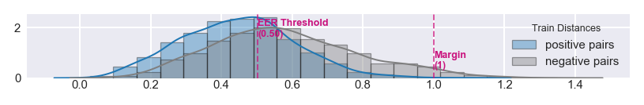

```
VALID: roc_auc: 0.5813, eer: 0.4500, thres: 0.5109 => acc: 0.5506, f1: 0.5503
val_loss: 0.252, loss: 0.224
```

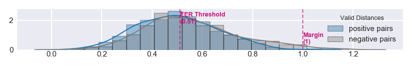

```
================================[   Epoch 16   ]================================
================================[   Epoch 17   ]================================
================================[   Epoch 18   ]================================
================================[   Epoch 19   ]================================
================================[   Epoch 20   ]================================
TRAIN: roc_auc: 0.6949, eer: 0.3639, thres: 0.4851 => acc: 0.6362, f1: 0.6361
val_loss: 0.251, loss: 0.219
```

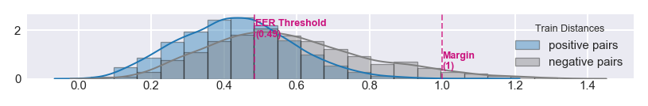

```
VALID: roc_auc: 0.5808, eer: 0.4602, thres: 0.5058 => acc: 0.5399, f1: 0.5402
val_loss: 0.251, loss: 0.219
```

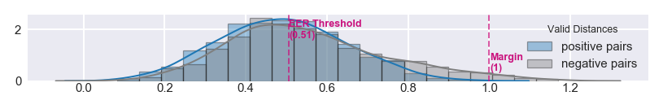

```
================================[   Epoch 21   ]================================
================================[   Epoch 22   ]================================
================================[   Epoch 23   ]================================
================================[   Epoch 24   ]================================
================================[   Epoch 25   ]================================
TRAIN: roc_auc: 0.7163, eer: 0.3473, thres: 0.4901 => acc: 0.6527, f1: 0.6526
val_loss: 0.252, loss: 0.216
```

[17 more figures not shown]

```python
# Select model architecture
model, basemodel = get_model(P.model_variant, P.window_size, P.feature_cols, P.filters)

# Select Optimizer
optimizer = get_optimizer(P.optimizer, P.optimizer_lr)

# Compile
warnings.filterwarnings("ignore")
model.compile(loss=k_contrastive_loss, optimizer=optimizer)

# Train
history = model.fit(
    x=X_train,
    y=y_train,
    batch_size=P.batch_size,
    epochs=P.epochs_max,
    verbose=0,
    validation_data=(X_valid, y_valid),
    callbacks=[MetricsCallback((X_valid, y_valid, X_train, y_train), epoch_evaluate_freq=5, save_plots=True)],
)

print("Training History:")
plt = utils_plot_training_loss(history)
utils_save_plot(
    plt, REPORT_PATH / f"buech2019-siamese-{P.name.lower()}-epoch-trainloss.pdf"
)
plt.show()
```

### 4.5 Check Distances

```python
# Predic validation set
dists = model.predict(X_valid)

# Stats
print(f"Mean distance: {dists.mean():.5f}")
print(f"Max distance: {dists.max():.5f}")
print(f"Min distance: {dists.min():.5f}\n")

# Histrogram
print("\nHistogram of Pair Distances:")
eer_val, thres = utils_eer(y_valid, dists, True)
mask = np.where(y_valid == 1, True, False)
dist_positive = dists[mask]
dist_negative = dists[~mask]
plt = utils_plot_distance_hist(dist_positive, dist_negative, thres, "Valid")

utils_save_plot(plt, REPORT_PATH / f"buech2019-siamese-{P.name.lower()}-dist-hist.pdf")
plt.show()
```

[output not shown]

### 4.6 Rebuild and train to optimal Epoch

Now, that we know the learning curve, we can rebuild the model and train it until the best Epoch.

Also, we will include the validation data to have more training data.

**Note:** This also means, that the training metrics are not valid anymore, because we don't have any validation data left to test against...

```python
# Concat train & valid data
X_train_valid = [[], []]
X_train_valid[0] = np.vstack([X_train[0], X_valid[0]])
X_train_valid[1] = np.vstack([X_train[1], X_valid[1]])
y_train_valid = np.hstack([y_train, y_valid])

# Select model architecture
model, basemodel = get_model(P.model_variant, P.window_size, P.feature_cols, P.filters)

# Select Optimizer
optimizer = get_optimizer(P.optimizer, P.optimizer_lr)

# Compile
model.compile(loss=k_contrastive_loss, optimizer=optimizer)

# Train
history = model.fit(
    x=X_train_valid,
    y=y_train_valid,
    batch_size=P.batch_size,
    epochs=P.epochs_best,
    verbose=0,
    callbacks=[MetricsCallback((None, None, X_train, y_train), epoch_evaluate_freq=10, save_plots=False)],
)
```

### 4.7 Cache model

```python
model.save(str((OUTPUT_PATH / f"{P.name}_model.h5").resolve()))
```

```python
# Clean Memory
%reset_selective -f df_
%reset_selective -f X_
%reset_selective -f y_
```

## 5. Visualize Deep Features

### 5.1 Load cached Data

```python
df_siamese_valid = pd.read_msgpack(OUTPUT_PATH / "df_siamese_valid.msg")
df_siamese_train = pd.read_msgpack(OUTPUT_PATH / "df_siamese_train.msg")

df_ocsvm_train_valid = pd.read_msgpack(OUTPUT_PATH / "df_ocsvm_train_valid.msg")
```

### 5.2 Extract CNN from Siamese Model

I do this by redirecting inputs and outputs.

However, the network still needs a pair as input (I wasn't able to change this). This slows down a little bit the prediction (as the input is predicted twice), but doesn't change the results.

```python
def load_deep_feature_model(model_path):
    # Copy of function from above. It's just more convenient for partially
    # executing the notebook.
    def k_contrastive_loss(y_true, dist):
        """Contrastive loss from Hadsell-et-al.'06
        http://yann.lecun.com/exdb/publis/pdf/hadsell-chopra-lecun-06.pdf
        """
        margin = P.margin
        return K.mean(
            y_true * K.square(dist)
            + (1 - y_true) * K.square(K.maximum(margin - dist, 0))
        )

    # Load Trained Siamese Network
    model = load_model(
        str(model_path.resolve()),
        custom_objects={"k_contrastive_loss": k_contrastive_loss},
    )

    # Extract one of the child networks
    deep_feature_model = Model(
        inputs=model.get_input_at(0),  # get_layer("left_inputs").input,
        outputs=model.get_layer("basemodel").get_output_at(1),
    )

    return deep_feature_model
```

```python
deep_feature_model = load_deep_feature_model(OUTPUT_PATH / f"{P.name}_model.h5")
deep_feature_model.summary()
```

### 5.3 Test Generation of Deep Features

```python
def prep_X_y_single(df):
    X = np.stack(list(df["X"].values))
    y = df["label"].values
    return X, y
```

```python
def transform_to_sample_by_subject(df):
    sample_by_subject = []
    df["label"] = 1
    for subj in df["subject"].unique():
        df_subj = df[df["subject"] == subj]
        X_sub, y_sub = prep_X_y_single(df_subj)
        sample_by_subject.append((X_sub, y_sub, subj))
    return sample_by_subject
```

#### Select subset (for plotting) and transform features

```python
# Concat Valid & Train (both were used for last Training)
df_train_temp = pd.concat([df_siamese_valid, df_siamese_train])
df_test_temp = df_ocsvm_train_valid

# Select data from 20 subjects of the TRAINING SET
random.seed(SEED)
ten_subjects = random.sample(df_train_temp["subject"].unique().tolist(), 20)
df_train_temp = df_train_temp[df_train_temp["subject"].isin(ten_subjects)].copy()
df_train_temp = df_train_temp.groupby("subject").apply(lambda x: x.sample(n=300, random_state=SEED))  # Plot only subset of samples

# Select data from 10 subjects of the TEST SET (not included in training)
random.seed(SEED)
ten_subjects = random.sample(df_test_temp["subject"].unique().tolist(), 10)
df_test_temp = df_test_temp[df_ocsvm_train_valid["subject"].isin(ten_subjects)].copy()
df_test_temp = df_test_temp.groupby("subject").apply(lambda x: x.sample(n=300, random_state=SEED))  # Plot only subset of samples

# Transform Samples
samples_train = transform_to_sample_by_subject(df_train_temp)
samples_test = transform_to_sample_by_subject(df_test_temp)

print(f"First subject: {samples_train[0][2]}")
print(f"y shape: {samples_train[0][1].shape}")
print(f"X shape: {samples_train[0][0].shape}")
```

#### Predict Deep Features

```python
deep_features_train = None
for X, y, subj in samples_train:
    if P.model_variant == "2d":
        X = X.reshape((*X.shape, 1))
    pred = deep_feature_model.predict([X, X])
    df_features = pd.DataFrame(pred)
    df_features["subject"] = subj
    deep_features_train = pd.concat([deep_features_train, df_features])

deep_features_test = None
for X, y, subj in samples_test:
    if P.model_variant == "2d":
        X = X.reshape((*X.shape, 1))
    pred = deep_feature_model.predict([X, X])
    df_features = pd.DataFrame(pred)
    df_features["subject"] = subj
    deep_features_test = pd.concat([deep_features_test, df_features])

display(deep_features_train.head(3))
display(deep_features_test.head(3))
```

### 5.4 Visualize in 2D using PCA

```python
def plot_pca(df):
    # PCA
    pca = PCA(n_components=2)
    deep_transformed = pca.fit_transform(df.drop(columns=["subject"]).values)

    # Create df with data needed for chart only
    df_viz = df.copy()
    df_viz["PCA0"] = deep_transformed[:, 0]
    df_viz["PCA1"] = deep_transformed[:, 1]
    df_viz.drop(
        columns=[c for c in df_viz.columns if c not in ["PCA0", "PCA1", "subject"]]
    )

    # Generate color index for every subject
    df_viz["Subject"] = pd.Categorical(df_viz["subject"])
    df_viz["colors"] = df_viz["Subject"].cat.codes

    if len(df_viz["Subject"].unique()) <= 10:
        pal = sns.color_palette("tab10")
    else:
        pal = sns.color_palette("tab20")

    # Actual plot
    fig = plt.figure(figsize=(5.473 / 1.5, 5.473 / 2), dpi=180)
    sns.scatterplot(
        x="PCA0",
        y="PCA1",
        data=df_viz,
        hue="Subject",
        legend="full",
        palette=pal,
        s=2,
        linewidth=0,
        alpha=0.6,
    )
    plt.legend(bbox_to_anchor=(1.05, 1), loc=2, borderaxespad=0, fontsize=5)
    fig.tight_layout()
    return plt
```

```python
plot_pca(deep_features_train)
utils_save_plot(plt, REPORT_PATH / f"buech2019-siamese-{P.name.lower()}-pca-train.pdf")
```

[output not shown]

```python
plot_pca(deep_features_test)
utils_save_plot(plt, REPORT_PATH / f"buech2019-siamese-{P.name.lower()}-pca-test.pdf")
```

[output not shown]

```python
### Cleanup memory
%reset_selective -f df_
%reset_selective -f X_
%reset_selective -f y_
%reset_selective -f pca
```

## 6. OCSVM

### 6.1 Load cached Data

```python
df_ocsvm_train_valid = pd.read_msgpack(OUTPUT_PATH / "df_ocsvm_train_valid.msg")
df_ocsvm_train_valid.head()
```

### 6.2 Load trained Siamese Model

**Helper methods to load model:**

```python
def load_deep_feature_model(model_path):
    warnings.filterwarnings("ignore")  # Silence depr. warnings

    # Copy of function from above. It's just more convenient for partially executing the notebook.
    def k_contrastive_loss(y_true, dist):
        """Contrastive loss from Hadsell-et-al.'06
        http://yann.lecun.com/exdb/publis/pdf/hadsell-chopra-lecun-06.pdf
        """
        margin = P.margin
        return K.mean(
            y_true * K.square(dist)
            + (1 - y_true) * K.square(K.maximum(margin - dist, 0))
        )

    # Load Trained Siamese Network
    model = load_model(
        str(model_path.resolve()),
        custom_objects={"k_contrastive_loss": k_contrastive_loss},
    )

    # Extract one of the child networks
    deep_feature_model = Model(
        inputs=model.get_input_at(0),  # get_layer("left_inputs").input,
        outputs=model.get_layer("basemodel").get_output_at(1),
    )

    return deep_feature_model
```

### 6.3 Search for Parameters

```python
df_ocsvm_train_valid.head()
```

```python
param_dist = {"gamma": np.logspace(-3, 3), "nu": np.linspace(0.0001, 0.3)}

# Load Siamese CNN Model
deep_feature_model = load_deep_feature_model(OUTPUT_PATH / f"{P.name}_model.h5")

df_results = None  # Will be filled with randomsearch scores

for run in tqdm(range(3)):
    for df_cv_scenarios, owner, impostors in tqdm(
        utils_generate_cv_scenarios(
            df_ocsvm_train_valid,
            samples_per_subject_train=P.samples_per_subject_train,
            samples_per_subject_test=P.samples_per_subject_test,
            seed=SEED + run,
            scaler=P.scaler,
            scaler_global=P.scaler_global,
            scaler_scope=P.scaler_scope,
            deep_model=deep_feature_model,
            model_variant=P.model_variant,
            feature_cols=P.feature_cols,
        ),
        desc="Owner",
        total=df_ocsvm_train_valid["subject"].nunique(),
        leave=False,
    ):

        X = np.array(df_cv_scenarios["X"].values.tolist())
        y = df_cv_scenarios["label"].values

        train_valid_cv = utils_create_cv_splits(df_cv_scenarios["mask"].values, SEED)

        model = OneClassSVM(kernel="rbf")

        warnings.filterwarnings("ignore")
        random_search = RandomizedSearchCV(
            model,
            param_distributions=param_dist,
            cv=train_valid_cv,
            n_iter=80,
            n_jobs=CORES,
            refit=False,
            scoring={"eer": utils_eer_scorer, "accuracy": "accuracy"},
            verbose=0,
            return_train_score=False,
            iid=False,
            error_score=np.nan,
            random_state=SEED,
        )

        random_search.fit(X, y)

        df_report = utils_cv_report(random_search, owner, impostors)
        df_report["run"] = run
        df_results = pd.concat([df_results, df_report], sort=False)

df_results.to_csv(OUTPUT_PATH / f"{P.name}_random_search_results.csv", index=False)
```

### 6.4 Inspect Search Results

**Raw Results & Stats:**

```python
df_results = pd.read_csv(OUTPUT_PATH / f"{P.name}_random_search_results.csv")
print("Best results for each owner:")

display(
    df_results[df_results["rank_test_eer"] <= 1][
        [
            "owner",
            "param_nu",
            "param_gamma",
            "rank_test_eer",
            "mean_test_eer",
            "std_test_eer",
            "mean_test_accuracy",
            "std_test_accuracy",
        ]
    ].sort_values("mean_test_eer").head(10)
)

print("\n\n\nMost relevant statistics:")
display(
    df_results[df_results["rank_test_eer"] <= 1][
        [
            "mean_fit_time",
            "param_nu",
            "param_gamma",
            "mean_test_accuracy",
            "std_test_accuracy",
            "mean_test_eer",
            "std_test_eer",
        ]
    ].describe()
)
```

[output not shown]

**Plot parameters of top n of 30 results for every Owner:**

```python
utils_plot_randomsearch_results(df_results, 1)
utils_save_plot(plt, REPORT_PATH / f"buech2019-siamese-{P.name.lower()}-parameters.pdf")
```

[output not shown]

## 7. Testing

### 7.1 Load cached Data

During testing, a split with different users than used for hyperparameter optimization is used:

```python
df_ocsvm_train_test = pd.read_msgpack(OUTPUT_PATH / "df_ocsvm_train_test.msg")
```

### 7.2 Evaluate Authentication Performance

- Using Testing Split, Scenario Cross Validation, and multiple runs to lower impact of random session/sample selection.

```python
# Load Siamese CNN Model
deep_feature_model = load_deep_feature_model(OUTPUT_PATH / f"{P.name}_model.h5")

df_results = None  # Will be filled with cv scores
for i in tqdm(range(5), desc="Run", leave=False):  # Run whole test 5 times
    for df_cv_scenarios, owner, impostors in tqdm(
        utils_generate_cv_scenarios(
            df_ocsvm_train_test,
            samples_per_subject_train=P.samples_per_subject_train,
            samples_per_subject_test=P.samples_per_subject_test,
            seed=SEED,
            scaler=P.scaler,
            scaler_global=P.scaler_global,
            scaler_scope=P.scaler_scope,
            deep_model=deep_feature_model,
            model_variant=P.model_variant,
            feature_cols=P.feature_cols,
        ),
        desc="Owner",
        total=df_ocsvm_train_test["subject"].nunique(),
        leave=False,
    ):

        X = np.array(df_cv_scenarios["X"].values.tolist())
        y = df_cv_scenarios["label"].values

        train_test_cv = utils_create_cv_splits(df_cv_scenarios["mask"].values, SEED)

        model = OneClassSVM(kernel="rbf", nu=P.ocsvm_nu, gamma=P.ocsvm_gamma)

        warnings.filterwarnings("ignore")
        scores = cross_validate(
            model,
            X,
            y,
            cv=train_test_cv,
            scoring={"eer": utils_eer_scorer, "accuracy": "accuracy"},
            n_jobs=CORES,
            verbose=0,
            return_train_score=True,
        )
        df_score = pd.DataFrame(scores)
        df_score["owner"] = owner
        df_score["train_eer"] = df_score["train_eer"].abs()  # Revert scorer's signflip
        df_score["test_eer"] = df_score["test_eer"].abs()
        df_results = pd.concat([df_results, df_score], axis=0)

df_results.to_csv(OUTPUT_PATH / f"{P.name}_test_results.csv", index=False)
df_results.head()
```

**Load Results from "EER & Accuracy" evaluation & prepare for plotting:**

```python
df_results = pd.read_csv(OUTPUT_PATH / f"{P.name}_test_results.csv")
df_plot = df_results.rename(
    columns={"test_accuracy": "Test Accuracy", "test_eer": "Test EER", "owner": "Owner"}
).astype({"Owner": str})
```

**Plot Distribution of Accuracy per subject:**

```python
fig = utils_plot_acc_eer_dist(df_plot, "Test Accuracy")
utils_save_plot(plt, REPORT_PATH / f"buech2019-siamese-{P.name.lower()}-acc.pdf")
```

[output not shown]

**Plot Distribution of EER per subject:**

```python
fig = utils_plot_acc_eer_dist(df_plot, "Test EER")
utils_save_plot(plt, REPORT_PATH / f"buech2019-siamese-{P.name.lower()}-eer.pdf")
```

[output not shown]

### 7.3 Evaluate increasing Training Set Size (Training Delay)

```python
training_set_sizes = [1, 2, 3, 4, 10, 30, 60, 90, 125, 175, 250, 375]  # In samples

deep_feature_model = load_deep_feature_model(OUTPUT_PATH / f"{P.name}_model.h5")

df_results = None  # Will be filled with cv scores
for i in tqdm(range(5), desc="Run", leave=False):  # Run whole test 5 times
    for n_train_samples in tqdm(training_set_sizes, desc="Train Size", leave=False):
        for df_cv_scenarios, owner, impostors in tqdm(
            utils_generate_cv_scenarios(
                df_ocsvm_train_test,
                samples_per_subject_train=P.samples_per_subject_train,
                samples_per_subject_test=P.samples_per_subject_test,
                limit_train_samples=n_train_samples,  # samples overall
                seed=SEED + i,
                scaler=P.scaler,
                scaler_global=P.scaler_global,
                scaler_scope=P.scaler_scope,
                deep_model=deep_feature_model,
                model_variant=P.model_variant,
                feature_cols=P.feature_cols,
            ),
            desc="Owner",
            total=df_ocsvm_train_test["subject"].nunique(),
            leave=False,
        ):
            X = np.array(df_cv_scenarios["X"].values.tolist())
            y = df_cv_scenarios["label"].values

            train_test_cv = utils_create_cv_splits(df_cv_scenarios["mask"].values, SEED)

            model = OneClassSVM(kernel="rbf", nu=P.ocsvm_nu, gamma=P.ocsvm_gamma)

            warnings.filterwarnings("ignore")
            scores = cross_validate(
                model,
                X,
                y,
                cv=train_test_cv,
                scoring={"eer": utils_eer_scorer},
                n_jobs=CORES,
                verbose=0,
                return_train_score=True,
            )
            df_score = pd.DataFrame(scores)
            df_score["owner"] = owner
            df_score["train_samples"] = n_train_samples
            df_score["train_eer"] = df_score[
                "train_eer"
            ].abs()  # Revert scorer's signflip
            df_score["test_eer"] = df_score["test_eer"].abs()
            df_results = pd.concat([df_results, df_score], axis=0)

df_results.to_csv(OUTPUT_PATH / f"{P.name}_train_delay_results.csv", index=False)
df_results.head()
```

**Load Results from "Training set size" evaluation & prepare for plotting:**

```python
df_results = pd.read_csv(OUTPUT_PATH / f"{P.name}_train_delay_results.csv")
df_plot = (
    df_results[["test_eer", "owner", "train_samples"]]
    .groupby(["owner", "train_samples"], as_index=False)
    .mean()
    .astype({"owner": "category"})
    .rename(
        columns={
            "test_eer": "Test EER",
            "owner": "Owner",
        }
    )
)
df_plot["Training Data in Seconds"] = df_plot["train_samples"] * P.window_size / P.frequency
```

**Plot EER with increasing number of training samples:**

```python
utils_plot_training_delay(df_plot)
utils_save_plot(plt, REPORT_PATH / f"buech2019-siamese-{P.name.lower()}-train-size.pdf")
```

[output not shown]

### 7.4 Evaluate increasing Test Set Sizes (Detection Delay)

```python
# Load Siamese CNN Model
deep_feature_model = load_deep_feature_model(OUTPUT_PATH / f"{P.name}_model.h5")

df_results = None  # Will be filled with cv scores
for i in tqdm(range(50), desc="Run", leave=False):  # Run whole test 5 times
    for df_cv_scenarios, owner, impostors in tqdm(
        utils_generate_cv_scenarios(
            df_ocsvm_train_test,
            samples_per_subject_train=P.samples_per_subject_train,
            samples_per_subject_test=P.samples_per_subject_test,
            limit_test_samples=1,  # Samples overall
            seed=SEED + i,
            scaler=P.scaler,
            scaler_global=P.scaler_global,
            scaler_scope=P.scaler_scope,
            deep_model=deep_feature_model,
            model_variant=P.model_variant,
            feature_cols=P.feature_cols,
        ),
        desc="Owner",
        total=df_ocsvm_train_test["subject"].nunique(),
        leave=False,
    ):
        X = np.array(df_cv_scenarios["X"].values.tolist())
        y = df_cv_scenarios["label"].values

        train_test_cv = utils_create_cv_splits(df_cv_scenarios["mask"].values, SEED)

        model = OneClassSVM(kernel="rbf", nu=P.ocsvm_nu, gamma=P.ocsvm_gamma)

        warnings.filterwarnings("ignore")
        scores = cross_validate(
            model,
            X,
            y,
            cv=train_test_cv,
            scoring={"eer": utils_eer_scorer},
            n_jobs=CORES,
            verbose=0,
            return_train_score=True,
        )
        df_score = pd.DataFrame(scores)
        df_score["owner"] = owner
        df_score["run"] = i
        df_score["train_eer"] = df_score["train_eer"].abs()  # Revert scorer's signflip
        df_score["test_eer"] = df_score["test_eer"].abs()
        df_results = pd.concat([df_results, df_score], axis=0)

df_results.to_csv(OUTPUT_PATH / f"{P.name}_detect_delay_results.csv", index=False)
df_results.head()
```

**Load Results from "Detection Delay" evaluation & prepare for plotting:**

```python
df_results = pd.read_csv(OUTPUT_PATH / f"{P.name}_detect_delay_results.csv")
df_results["owner"] = df_results["owner"].astype(str)
df_plot = df_results.copy()
```

**Plot Expanding Mean EER and confidence interval:**

```python
utils_plot_detect_delay(df_plot, factor=P.window_size / P.frequency, xlim=160)
utils_save_plot(
    plt, REPORT_PATH / f"buech2019-siamese-{P.name.lower()}-detection-delay.pdf"
)
```

[output not shown]